# MB5370 Module 04. Data Science in R 4

Ivanya Johnson

2024-09-10

# Workshop 4: Spatial Data in R

## Installing / Loading Spatial Packages

I have already installed these packages so I have hashtagged the installation code out.

```r
# install.packages("sf")
# install.packages("terra")
# install.packages("tmap")

library(tidyverse)
```

```r
library(ggplot2)

library(sf) # simple features
library(terra) # raster
library(tmap) # Thematic maps are geographical maps in which spatial data distributions are visualized
library(readr)
```

## Importing Copepod Data

```r
dat <- read_csv("../data-for-course/copepods_raw.csv") # Because I am in a different working directory, I need to tell R to go back and find the folder titled data-for-course to find the copepods csv
dat
```

```
## # A tibble: 5,313 × 11
##    silk_id segment_no latitude longitude sample_time_utc  project route vessel
##      <dbl>      <dbl>    <dbl>     <dbl> <chr>            <chr>   <chr> <chr>
##  1       1          1    -28.3      154. 26/06/2009 22:08 AusCPR  BRSY  ANL Win…
##  2       1          5    -28.7      154. 26/06/2009 23:12 AusCPR  BRSY  ANL Win…
##  3       1          9    -29.0      154. 27/06/2009 0:17  AusCPR  BRSY  ANL Win…
##  4       1         13    -29.3      154. 27/06/2009 1:22  AusCPR  BRSY  ANL Win…
##  5       1         17    -29.7      154. 27/06/2009 2:26  AusCPR  BRSY  ANL Win…
##  6       1         18    -29.8      154. 27/06/2009 2:43  AusCPR  BRSY  ANL Win…
##  7       1         26    -30.4      153. 27/06/2009 4:52  AusCPR  BRSY  ANL Win…
##  8       1         30    -30.7      153. 27/06/2009 5:57  AusCPR  BRSY  ANL Win…
##  9       1         33    -31.0      153. 27/06/2009 6:45  AusCPR  BRSY  ANL Win…
## 10       1         37    -31.3      153. 27/06/2009 7:50  AusCPR  BRSY  ANL Win…
## # ℹ 5,303 more rows
## # ℹ 3 more variables: meanlong <dbl>, region <chr>, richness_raw <dbl>
```

## Data Exploration

### Check Coordinates

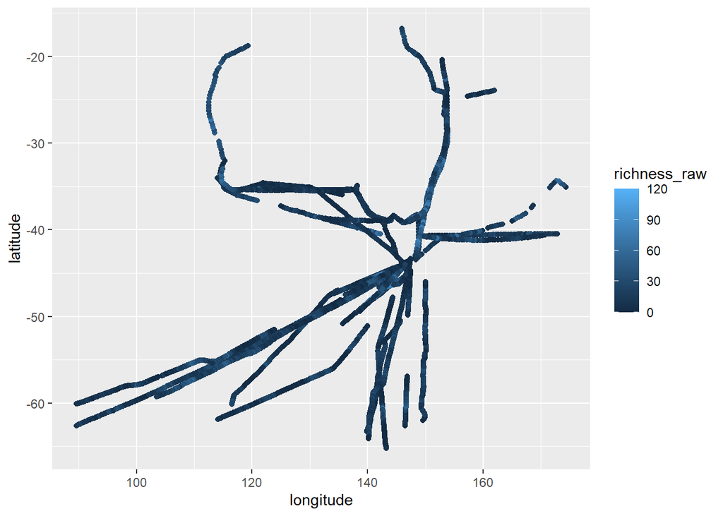

```r
ggplot(dat) +
  aes(x = longitude, y = latitude, color = richness_raw) +
  geom_point()
```

Add the stat_smooth function

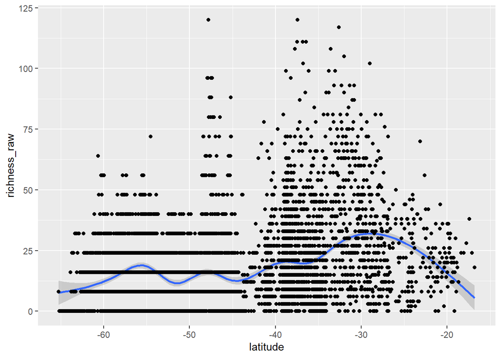

```r
ggplot(dat, aes(x = latitude, y = richness_raw)) +
  stat_smooth() +
  geom_point()
```

### Get Going With Maps

```r
sdat <- st_as_sf(dat, coords = c("longitude", "latitude"),
                 crs = 4326)
```

```r
?st_as_sf
```

```
## starting httpd help server ... done
```

st_as_sf converts different data types to simple features - coords gives the names of the columns that relate to the spatial coordinates (in order of X coordinate followed by Y coordinate)

### Coordinate Reference System

- crs stands for ‘coordinate reference system’
- CRS are required for 2D mapping to compensate for the lumpy, spherical (3D) nature of the earth

```r
crs4326 <- st_crs(4326)

crs4326 # Look at the whole crs
```

```
## Coordinate Reference System:
##   User input: EPSG:4326
##   wkt:
## GEOGCRS["WGS 84",
##     ENSEMBLE["World Geodetic System 1984 ensemble",
##         MEMBER["World Geodetic System 1984 (Transit)"],
##         MEMBER["World Geodetic System 1984 (G730)"],
##         MEMBER["World Geodetic System 1984 (G873)"],
##         MEMBER["World Geodetic System 1984 (G1150)"],
##         MEMBER["World Geodetic System 1984 (G1674)"],
##         MEMBER["World Geodetic System 1984 (G1762)"],
##         MEMBER["World Geodetic System 1984 (G2139)"],
##         ELLIPSOID["WGS 84",6378137,298.257223563,
##             LENGTHUNIT["metre",1]],
##         ENSEMBLEACCURACY[2.0]],
##     PRIMEM["Greenwich",0,
##         ANGLEUNIT["degree",0.0174532925199433]],
##     CS[ellipsoidal,2],
##         AXIS["geodetic latitude (Lat)",north,
##             ORDER[1],
##             ANGLEUNIT["degree",0.0174532925199433]],
##         AXIS["geodetic longitude (Lon)",east,
##             ORDER[2],
##             ANGLEUNIT["degree",0.0174532925199433]],
##     USAGE[
##         SCOPE["Horizontal component of 3D system."],
##         AREA["World."],
##         BBOX[-90,-180,90,180]],
##     ID["EPSG",4326]]
```

```r
crs4326$Name
```

```
## [1] "WGS 84"
```

```r
crs4326$wkt
```

```
## [1] "GEOGCRS[\"WGS 84\",\n    ENSEMBLE[\"World Geodetic System 1984 ensemble\",\n        MEMBER[\"World Geodetic System 1984 (Transit)\"],\n        MEMBER[\"World Geodetic System 1984 (G730)\"],\n        MEMBER[\"World Geodetic System 1984 (G873)\"],\n        MEMBER[\"World Geodetic System 1984 (…
```

### Feature Collection (Points)

```r
sdat
```

```
## Simple feature collection with 5313 features and 9 fields
## Geometry type: POINT
## Dimension:     XY
## Bounding box:  xmin: 89.6107 ymin: -65.2428 xmax: 174.335 ymax: -16.80253
## Geodetic CRS:  WGS 84
## # A tibble: 5,313 × 10
##    silk_id segment_no sample_time_utc  project route vessel      meanlong region
##  *   <dbl>      <dbl> <chr>            <chr>   <chr> <chr>          <dbl> <chr>
##  1       1          1 26/06/2009 22:08 AusCPR  BRSY  ANL Windar…     153. East
##  2       1          5 26/06/2009 23:12 AusCPR  BRSY  ANL Windar…     153. East
##  3       1          9 27/06/2009 0:17  AusCPR  BRSY  ANL Windar…     153. East
##  4       1         13 27/06/2009 1:22  AusCPR  BRSY  ANL Windar…     153. East
##  5       1         17 27/06/2009 2:26  AusCPR  BRSY  ANL Windar…     153. East
##  6       1         18 27/06/2009 2:43  AusCPR  BRSY  ANL Windar…     153. East
##  7       1         26 27/06/2009 4:52  AusCPR  BRSY  ANL Windar…     153. East
##  8       1         30 27/06/2009 5:57  AusCPR  BRSY  ANL Windar…     153. East
##  9       1         33 27/06/2009 6:45  AusCPR  BRSY  ANL Windar…     153. East
## 10       1         37 27/06/2009 7:50  AusCPR  BRSY  ANL Windar…     153. East
## # ℹ 5,303 more rows
## # ℹ 2 more variables: richness_raw <dbl>, geometry <POINT [°]>
```

### Cartography

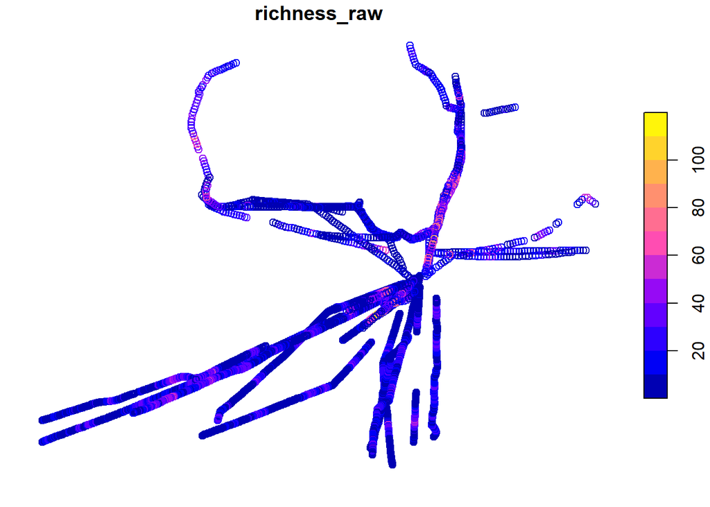

```r
plot(sdat["richness_raw"])
```

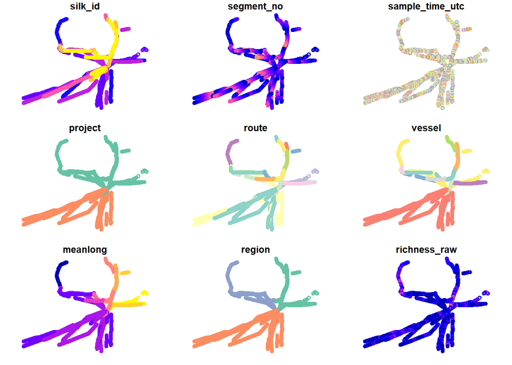

```r
plot(sdat)
```

## Thematic Maps for Communication

### Using tmap

- tm_dots to plot dots of the coordinates. Other options are tm_polygons and tm_symbols

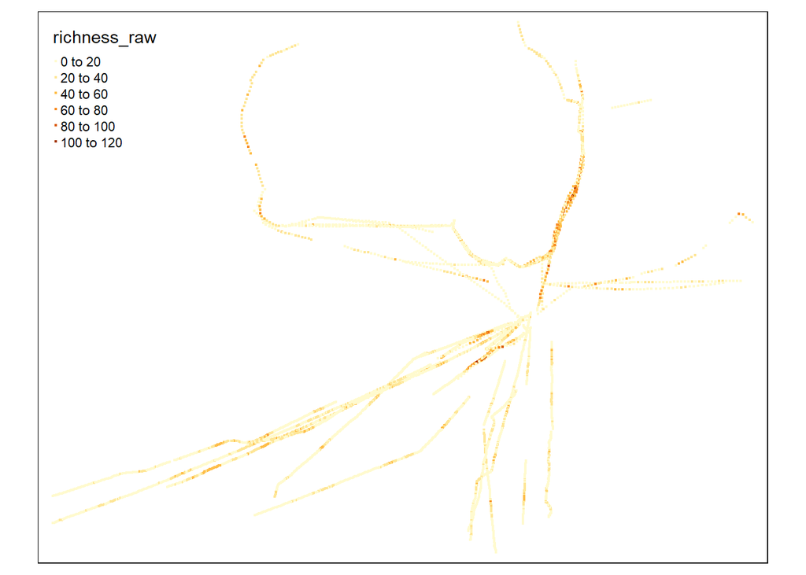

```r
tm_shape(sdat) +
  tm_dots(col = "richness_raw")
```

Use tmap_save to save the map to your working directory

```r
tmap_save(filename = "Richness-map.png",
          width = 600, height = 600)
```

```
## Map saved to C:\Users\biogi\OneDrive\Desktop\RStudio\MB5370 Practicals\My_Github_Crap\IJohnson_Module_04\code\Richness-map.png
```

```
## Resolution: 600 by 600 pixels
```

```
## Size: 2 by 2 inches (300 dpi)
```

## Mapping Spatial Polygons as Layers

### Loading Shapefiles

Shapefiles are not ideal as they’re inefficient at storing data and to save 1 shapefile you create multiple files. This means, a bit of the file might be lost if you transfer the data somewhere else.

```r
aus <- st_read("../data-for-course/spatial-data/Aussie/Aussie.shp")
shelf <- st_read("../data-for-course/spatial-data/aus_shelf/aus_shelf.shp")
aus
```

```
## Simple feature collection with 8 features and 1 field
## Geometry type: MULTIPOLYGON
## Dimension:     XY
## Bounding box:  xmin: 112.9211 ymin: -43.63192 xmax: 153.6389 ymax: -9.229614
## Geodetic CRS:  WGS 84
##   adm                       geometry
## 1 NSW MULTIPOLYGON (((141.0029 -3...
## 2 Vic MULTIPOLYGON (((140.9659 -3...
## 3 QLD MULTIPOLYGON (((153.5522 -2...
## 4  SA MULTIPOLYGON (((129.0013 -2...
## 5  WA MULTIPOLYGON (((129.0012 -1...
## 6 Tas MULTIPOLYGON (((148.3096 -4...
## 7  NT MULTIPOLYGON (((137.9962 -1...
## 8 ACT MULTIPOLYGON (((149.1253 -3...
```

```r
shelf
```

```
## Simple feature collection with 1 feature and 1 field
## Geometry type: MULTIPOLYGON
## Dimension:     XY
## Bounding box:  xmin: 112.2242 ymin: -44.1284 xmax: 153.8942 ymax: -8.8798
## Geodetic CRS:  GRS 1980(IUGG, 1980)
##   FID                       geometry
## 1   0 MULTIPOLYGON (((112.2267 -2...
```

### Mapping Polygons

Blank map of Australia

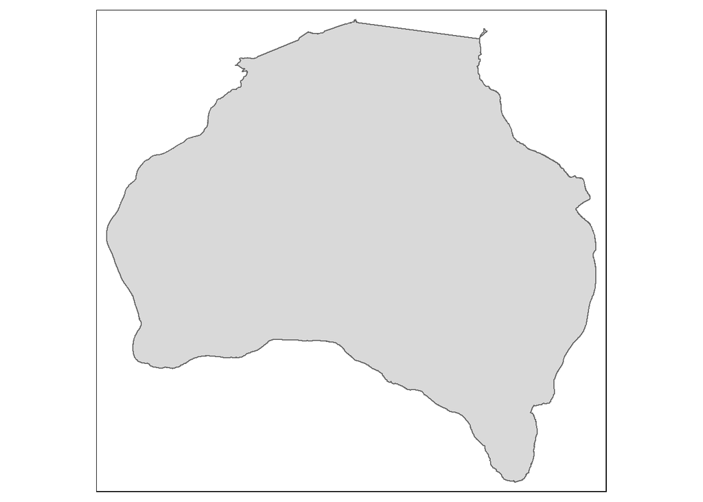

```r
tm_shape(shelf) +
  tm_polygons()
```

With this code, we see the data points

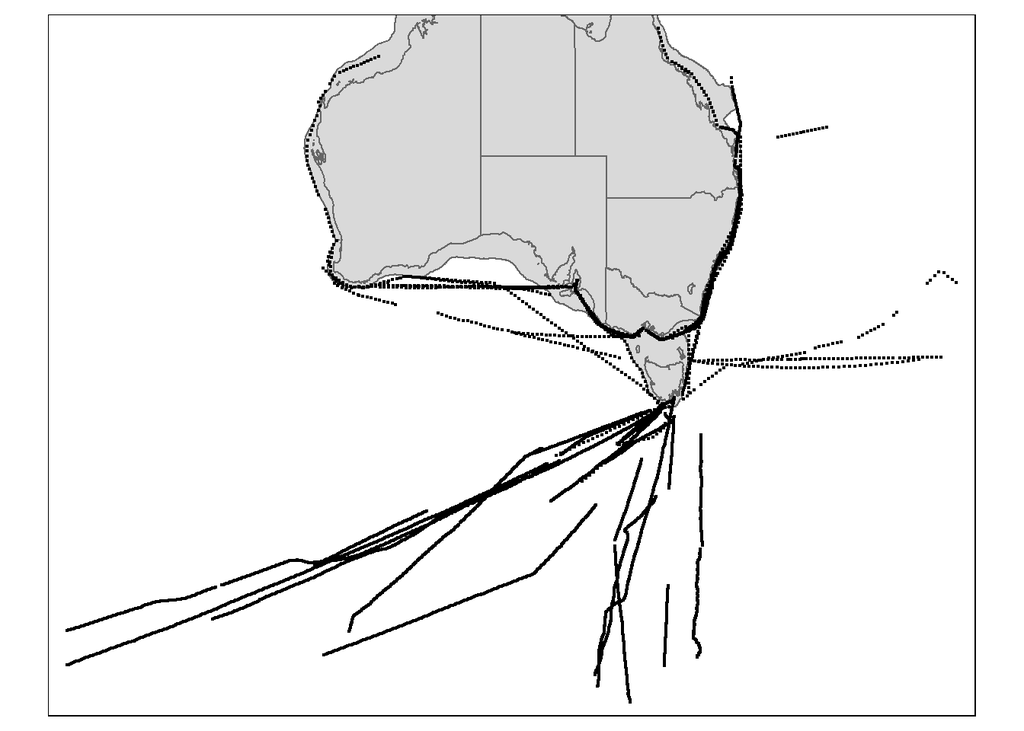

```r
tm_shape(shelf, bbox = sdat) +
  tm_polygons() +
  tm_shape(aus) +
  tm_polygons() +
  tm_shape(sdat) +
  tm_dots()
```

## Exploring tmap

Follow the instructions in the Help Window

```r
vignette('tmap-getstarted')
```

### Create a Map of the world

The object World is a spatial object of class sf from the sf package; it is a data.frame with a special column that contains a geometry for each row, in this case polygons. In order to plot it in tmap, you first need to specify it with tm_shape. Layers can be added with the + operator, in this case tm_polygons. There are many layer functions in tmap, which can easily be found in the documentation by their tm_ prefix. See also ?‘tmap-element’.

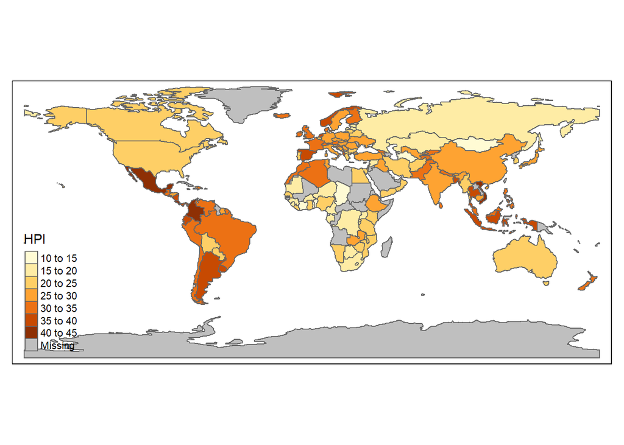

```r
data("World")

tm_shape(World) +
  tm_polygons("HPI")
```

### Interactive Maps

Each map can be plotted as a static image or viewed interactively using “plot” and “view” modes, respectively. The mode can be set with the function tmap_mode, and toggling between the modes can be done with the ‘switch’ ttm() (which stands for toggle thematic map.

```r
tmap_mode("view")
```

```
## tmap mode set to interactive viewing
```

```r
tm_shape(World) +
  tm_polygons("HPI")
```

[interactive chart not shown]

### Multiple shapes and layers

A shape is a spatial object (with a class from sf, sp, stars, or raster). Multiple shapes and also multiple layers per shape can be plotted.

```r
data(World, metro, rivers, land)

tmap_mode("plot")
```

```
## tmap mode set to plotting
```

```r
tm_shape(land) +
  tm_raster("elevation", palette = terrain.colors(10)) +
  tm_shape(World) +
  tm_borders("white", lwd = .5) +
  tm_text("iso_a3", size = "AREA") +
  tm_shape(metro) +
  tm_symbols(col = "red", size = "pop2020", scale = .5) +
  tm_legend(show = FALSE)
```

```
## old-style crs object detected; please recreate object with a recent sf::st_crs()
```

```
## old-style crs object detected; please recreate object with a recent sf::st_crs()
## old-style crs object detected; please recreate object with a recent sf::st_crs()
```

[figure not shown]

### Facets

Facets can be created in three ways:

1. By assigning multiple variable names to one aesthetic (in this example the first argument of tm_polygons:

```r
tmap_mode("view")
```

```
## tmap mode set to interactive viewing
```

```r
tm_shape(World) +
  tm_polygons(c("HPI", "economy")) +
  tm_facets(sync = TRUE, ncol = 2)
```

[interactive chart not shown]

2. By splitting the spatial data with the by argument of tm_facets:

```r
tmap_mode("plot")
```

```
## tmap mode set to plotting
```

```r
data(NLD_muni)

NLD_muni$perc_men <- NLD_muni$pop_men / NLD_muni$population * 100

tm_shape(NLD_muni) +
  tm_polygons("perc_men", palette = "RdYlBu") +
  tm_facets(by = "province")
```

```
## old-style crs object detected; please recreate object with a recent sf::st_crs()
```

```
## old-style crs object detected; please recreate object with a recent sf::st_crs()
## old-style crs object detected; please recreate object with a recent sf::st_crs()
## old-style crs object detected; please recreate object with a recent sf::st_crs()
## old-style crs object detected; please recreate object with a recent sf::st_crs()
```

[figure not shown]

3. By using the tmap_arrange function:

```r
tmap_mode("plot")
```

```
## tmap mode set to plotting
```

```r
data(NLD_muni)

tm1 <- tm_shape(NLD_muni) + tm_polygons("population", convert2density = TRUE)

tm2 <- tm_shape(NLD_muni) + tm_bubbles(size = "population")

tmap_arrange(tm1, tm2)
```

```
## old-style crs object detected; please recreate object with a recent sf::st_crs()
```

[output not shown]

```
## Legend labels were too wide. Therefore, legend.text.size has been set to 0.32. Increase legend.width (argument of tm_layout) to make the legend wider and therefore the labels larger.
```

[figure not shown]

### Basemaps and Overlay Tile Maps

Tiled basemaps can be added with the layer function tm_basemap. Semi-transparent overlay maps (for example annotation labels) can be added with tm_tiles.

```r
tmap_mode("view")
```

```
## tmap mode set to interactive viewing
```

```r
tm_basemap("Stamen.Watercolor") +
  tm_shape(metro) + tm_bubbles(size = "pop2020", col = "red") +
  tm_tiles("Stamen.TonerLabels")
```

```
## old-style crs object detected; please recreate object with a recent sf::st_crs()
```

```
## old-style crs object detected; please recreate object with a recent sf::st_crs()
## old-style crs object detected; please recreate object with a recent sf::st_crs()
## old-style crs object detected; please recreate object with a recent sf::st_crs()
## old-style crs object detected; please recreate object with a recent sf::st_crs()
```

```
## Legend for symbol sizes not available in view mode.
```

[interactive chart not shown]

Note: For some reason, the above code does not produce the map. it only produces the red bubbles!

### Options and Styles

The functions tm_layout and tm_view are used to specify the map layout and the interactive aspects respectively. These functions can be used in the same way as the layer functions.

```r
tmap_mode("plot")
```

```
## tmap mode set to plotting
```

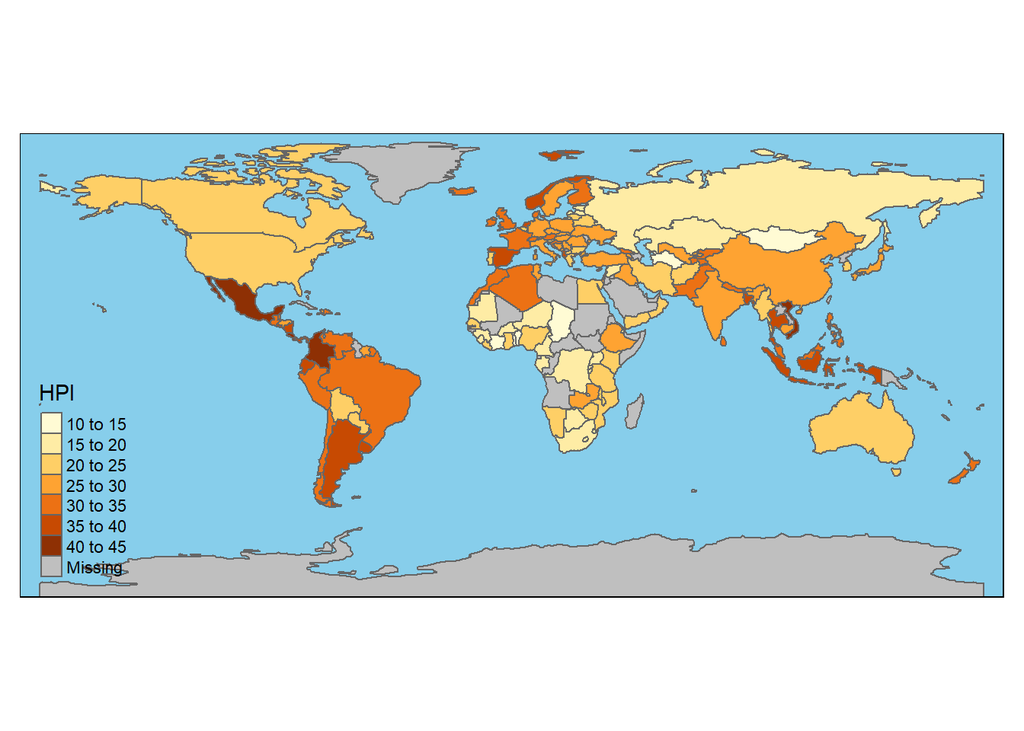

```r
tm_shape(World) +
  tm_polygons("HPI") +
  tm_layout(bg.color = "skyblue", inner.margins = c(0, .02, .02, .02))
```

These options, as well as a couple of others, can also be set within with tmap_options, which works in the same way as the base R function options. The main advantage is that these options are set globally, so they do not have to be specified in each map, for the duration of the session.

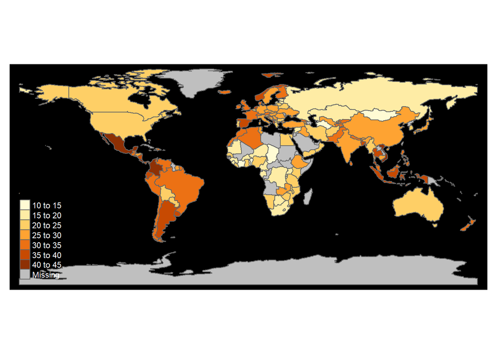

```r
tmap_options(bg.color = "black", legend.text.color = "white")

tm_shape(World) +
  tm_polygons("HPI", legend.title = "Happy Planet Index")
```

A style is a certain configuration of the tmap options.

```r
tmap_style("classic")
```

```
## tmap style set to "classic"
```

```
## other available styles are: "white", "gray", "natural", "cobalt", "col_blind", "albatross", "beaver", "bw", "watercolor"
```

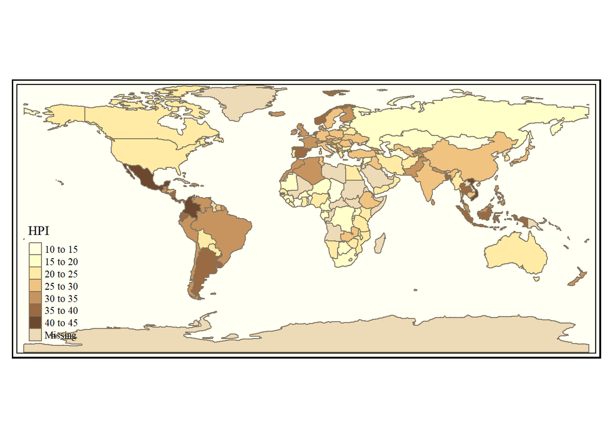

```r
tm_shape(World) +
  tm_polygons("HPI", legend.title = "Happy Planet Index")
```

```r
tmap_options_diff()
```

```
## current tmap options (style "classic") that are different from default tmap options (style "white"):
```

```
## $sepia.intensity
## [1] 0.7
##
## $frame.double.line
## [1] TRUE
##
## $fontfamily
## [1] "serif"
##
## $compass.type
## [1] "rose"
##
## $basemaps
## [1] "Esri.WorldTopoMap"
##
## $basemaps.alpha
## [1] 0.5
```

```r
tmap_options_reset()
```

```
## tmap options successfully reset
```

## Exporting Maps

The following is the code used to save the last map created

```r
?tmap_save

tm <- tm_shape(World) +
    tm_polygons("HPI", legend.title = "Happy Planet Index")

## save an image ("plot" mode)
tmap_save(tm, filename = "world_map.png")
```

```
## Map saved to C:\Users\biogi\OneDrive\Desktop\RStudio\MB5370 Practicals\My_Github_Crap\IJohnson_Module_04\code\world_map.png
```

```
## Resolution: 3053.984 by 1444.016 pixels
```

```
## Size: 10.17995 by 4.813385 inches (300 dpi)
```

```r
## save as stand-alone HTML file ("view" mode)
tmap_save(tm, filename = "world_map.html")
```

```
## Interactive map saved to C:\Users\biogi\OneDrive\Desktop\RStudio\MB5370 Practicals\My_Github_Crap\IJohnson_Module_04\code\world_map.html
```